# Predicting 2015 Citibike Trips

Gabrielle Martinez (Pace University)

6/19/2020

## Using a model trained on 2014 data to predict 2015 trends

First let’s load the 2015 data for cleaning and reformatting.

```r
load('trips2015.RData')

head(trips_per_day2015)
```

```
## # A tibble: 6 x 8
##   ymd        num_trips date        prcp  snwd  snow  tmax  tmin
##   <date>         <int> <chr>      <dbl> <dbl> <dbl> <int> <int>
## 1 2015-01-01      4387 2015-01-01  0        0     0    39    27
## 2 2015-01-02     10551 2015-01-02  0        0     0    42    35
## 3 2015-01-03      5824 2015-01-03  0.71     0     0    42    33
## 4 2015-01-04      7152 2015-01-04  0.3      0     0    56    41
## 5 2015-01-05     13488 2015-01-05  0        0     0    49    21
## 6 2015-01-06      9257 2015-01-06  0.05     0     1    22    19
```

Next let’s load our model and a function to add holiday data to `trips_per_day2015`

```r
load('predict_citibike_model.RData')

#add holiday and factor columns
modifiy_trips_data(trips_per_day2015) -> trips_per_day2015

head(trips_per_day2015)
```

```
## # A tibble: 6 x 13
##   ymd        num_trips date   prcp  snwd  snow  tmax  tmin holiday israining
##   <date>         <int> <chr> <dbl> <dbl> <dbl> <int> <int> <chr>   <lgl>
## 1 2015-01-01      4387 2015~  0        0     0    39    27 New Ye~ FALSE
## 2 2015-01-02     10551 2015~  0        0     0    42    35 <NA>    FALSE
## 3 2015-01-03      5824 2015~  0.71     0     0    42    33 <NA>    TRUE
## 4 2015-01-04      7152 2015~  0.3      0     0    56    41 <NA>    TRUE
## 5 2015-01-05     13488 2015~  0        0     0    49    21 <NA>    FALSE
## 6 2015-01-06      9257 2015~  0.05     0     1    22    19 <NA>    FALSE
## # ... with 3 more variables: day_of_week <fct>, isweekday <lgl>,
## #   isholiday <dbl>
```

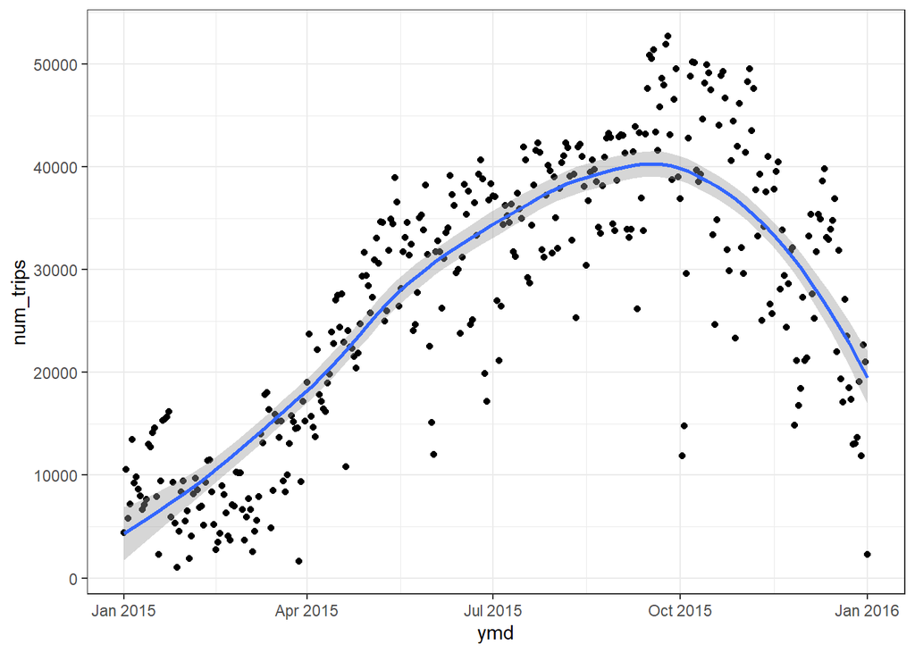

```r
#tmin, tmax are multiplied by 10

trips_per_day2015 %>%
  mutate(tmax = tmax/10, tmin = tmin/10) -> trips_per_day2015

ggplot(trips_per_day2015, aes(x=ymd, y=num_trips)) +
  geom_point() +
  geom_smooth()
```

`trips_perday2015` now has 5 more columns. `holiday` states the holiday for the day and `isholiday` states if the day is a holiday or not (1,0). `israining` states if it rained that day if the precipitation variable >= 0.1 inches. `day_of_week` tells what day of the week it is and based on that`isweekday` states if the day is a weekday or a weekend.

## Predicting 2015 trips per day

Using the following model we try to predict the trips per day

```r
tidy(model4)
```

```
## # A tibble: 8 x 5
##   term                        estimate std.error statistic  p.value
##   <chr>                          <dbl>     <dbl>     <dbl>    <dbl>
## 1 (Intercept)                    6911.    2481.      2.79  5.70e- 3
## 2 poly(tmin, 3, raw = T)1       -6227.    2013.     -3.09  2.18e- 3
## 3 poly(tmin, 3, raw = T)2        3213.     514.      6.25  1.47e- 9
## 4 poly(tmin, 3, raw = T)3        -267.      40.1    -6.66  1.40e-10
## 5 isholiday                     -8941.    1247.     -7.17  6.39e-12
## 6 israiningTRUE                 -6813.    1065.     -6.40  6.52e-10
## 7 isweekdayTRUE                  5865.     569.     10.3   2.28e-21
## 8 israiningTRUE:isweekdayTRUE    -853.    1238.     -0.688 4.92e- 1
```

```r
glance(model4)
```

```
## # A tibble: 1 x 11
##   r.squared adj.r.squared sigma statistic   p.value    df logLik   AIC   BIC
##       <dbl>         <dbl> <dbl>     <dbl>     <dbl> <int>  <dbl> <dbl> <dbl>
## 1     0.863         0.859 3826.      255. 1.71e-118     8 -2819. 5656. 5689.
## # ... with 2 more variables: deviance <dbl>, df.residual <int>
```

```r
#rmse_trips_2015
rmse(model4, trips_per_day2015)
```

```
## [1] 8051.339
```

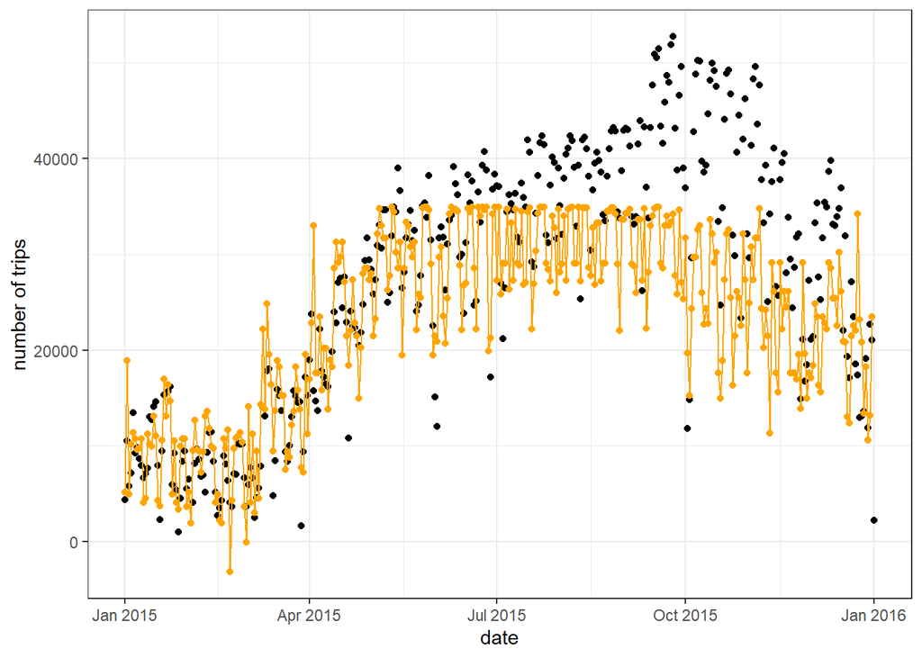

```r
trips_per_day2015 %>%
  add_predictions(model4) -> trips_per_day2015

ggplot(trips_per_day2015, aes(x=ymd, y=num_trips)) +
  geom_point() +
  geom_point(aes(y=pred), color = "orange") +
  geom_line(aes(y=pred),color = "orange") +
  ylab("number of trips")+
  xlab("date")
```

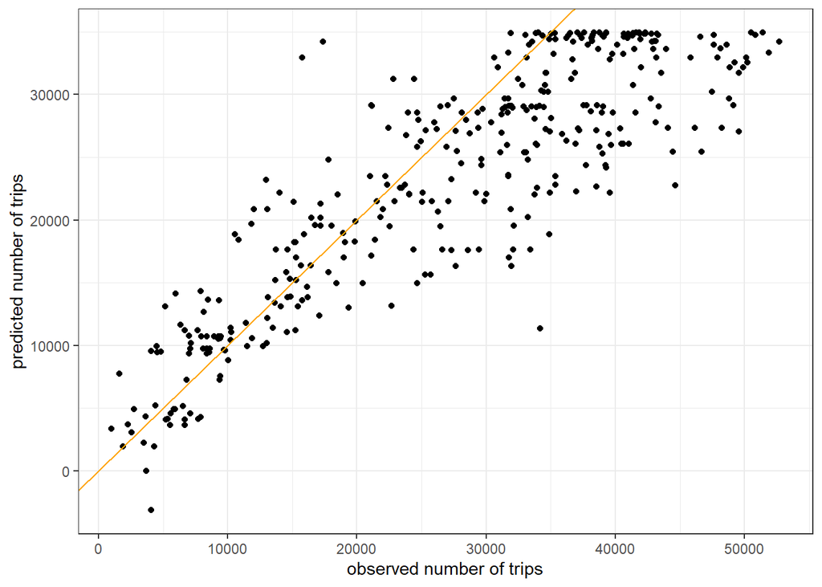

```r
ggplot(trips_per_day2015, aes(x=num_trips, y=pred))+
  geom_point()+
  geom_abline(color = "orange") +
  ylab("predicted number of trips") +
  xlab("observed number of trips")
```

## Outcomes

- The RMSE is much higher than my test on 2014 data.
- Plotting the date v. number of trips shows that the model is fairly good at predicting the first half of the year but low balls the predictions for the later half.
- Plotting the observed v. the predicted number of trips, you see that the plot has a diagoinal trend but that many more of the points lie below the 45 degree line (the 1:1 relationship). There’s also a wider variance as the number of trips increase.
- This model seems to be too conservative in its estimates.